# Milestone 1

Paweł Morgen, Dawid Przybyliński

## Metadane datasetu

Zbiór zawiera wyniki eksperymentu przeprowadzonego na grupie 30 osób z przedziału wikekowego 19-48 lat. Każda z osób wykonywała 6 czynności (chodzenie, chodzenie w górę po schodach, chodzenie w dół po schodach, siedzenie, stanie, leżenie). Zapisane zostały odczyty żyroskopu i akcelerometru ze smartfona umieszczonego przy pasie badanego. Domyślnie zbiór został podzielony na treningowy i testowy w proporcji 7 : 3, jednakże jako że narazie wykonujemy eksplorację danych, a następnym celem będzie klasteryzacja, połączyliśmy na początku te dwa zbiory. Warto też wspomnieć, że zbiór nie zawiera braków danych.

## Dane - pierwsze spojrzenie

```
## [1] "Number of features: 561"
```

W datasecie jest porażające 561 numerycznych, znormalizowanych (z przedziału $[-1,1]$) zmiennych. Opisują one:

- wskazania akcelerometru oraz żyroskopu w 3 wymiarach, przefiltrowane, by wyciszyć szumy
- przeliczone przyspieszenie ludzkie oraz grawitacyjne
- *zryw* (zmianę przyspieszenia w czasie, ang. *jerk*)
- przeliczoną *Fast Fourier Transform* .

Dla niemal każdej z powyższych zostały policzone statystyki (średnia, odchylenie, min/max, energia, entropia, …)

## Powiązania

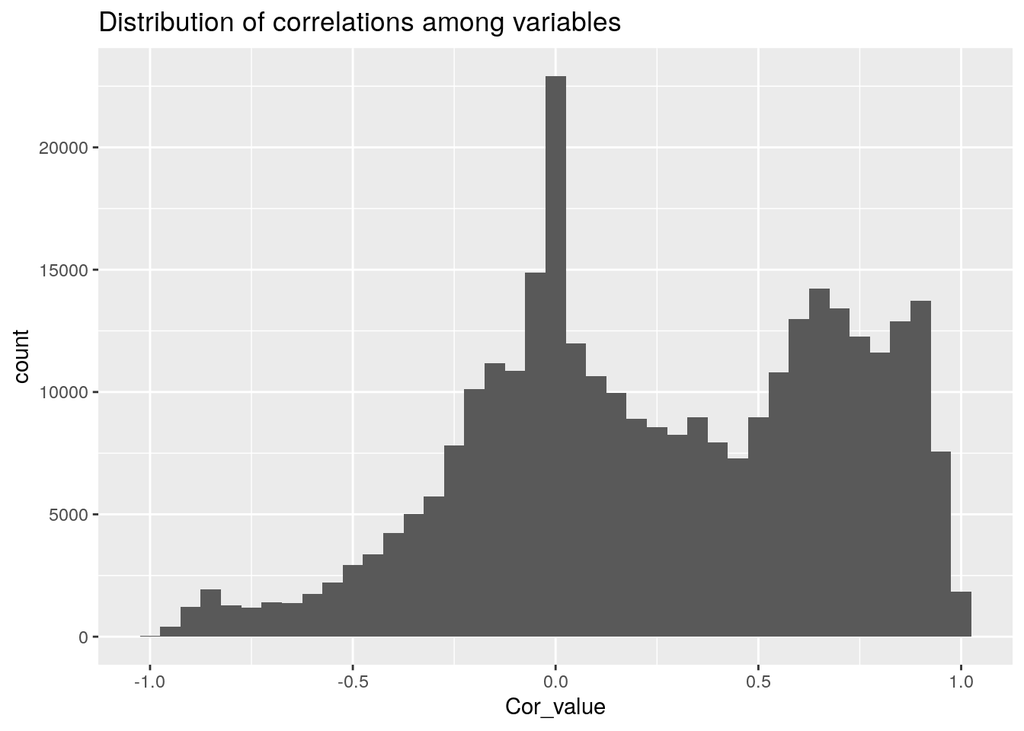

```r
# Uwaga - korelacje!
cor(X) -> cor_mat
cor_toplot <- data.frame(Cor_value = as.vector(cor_mat))
ggplot(cor_toplot, aes(x = Cor_value)) +
  geom_histogram(binwidth = 0.05) +
  labs(title = "Distribution of correlations among variables")
```

```r
f <- function(cutoff) (length(cor_mat[abs(cor_mat) > cutoff]) - ncol(X))
cutoffs <- c(0.7, 0.8, 0.9, 0.95, 0.99, 0.999)
knitr::kable(data.frame(
  Count = sapply(cutoffs, f) / 2,
  Percentile = round(sapply(cutoffs, f) / length(cor_mat), 4) * 100,
  Cutoff = cutoffs))
```

| Count | Percentile | Cutoff |
| --- | --- | --- |
| 36249 | 23.04 | 0.700 |
| 22815 | 14.50 | 0.800 |
| 8093 | 5.14 | 0.900 |
| 2219 | 1.41 | 0.950 |
| 207 | 0.13 | 0.990 |
| 43 | 0.03 | 0.999 |

Powyższa tabelka przedstawia, ile **par** zmiennych (`Count`) jest ze sobą skorelowana w stopniu wyższym niż `cutoff`. Jasno widać, że można sporo zyskać na czasie obliczeniowym, jeśli odrzucimy część zmiennych.

Wiedza na temat zmiennych pozwala nam dla celów eksploracji brać tylko zmienne traktujące o wartości średniej danego odczytu w danej osi w danej chwili.

```r
mean_features_names <- grep(x = colnames(X), pattern = "^[^_]+_mean(_.*)?$", value = TRUE)
X_mean <- X[,mean_features_names]
cor_mat <- cor(X_mean)
X_final <- X_mean[,c(sapply(1:(ncol(cor_mat)-1), function(i){
  all(abs(cor_mat[i, (i+1):ncol(cor_mat)]) < 0.95)
}), FALSE)]
```

Następujące zmienne mają wysoko skorelowane odpowiedniki:

```
##  [1] "tBodyAccMag_mean"          "tGravityAccMag_mean"
##  [3] "tBodyAccJerkMag_mean"      "tBodyGyroMag_mean"
##  [5] "tBodyGyroJerkMag_mean"     "fBodyAcc_mean_X"
##  [7] "fBodyAcc_mean_Y"           "fBodyAcc_mean_Z"
##  [9] "fBodyAccJerk_mean_X"       "fBodyAccJerk_mean_Y"
## [11] "fBodyGyro_mean_Y"          "fBodyAccMag_mean"
## [13] "fBodyBodyGyroMag_mean"     "fBodyBodyGyroJerkMag_mean"
```

```r
plot_corrgraph(X_final)
```

[interactive chart not shown]

Należy się spodziewać, że dla końcowego wyniku znaczenie mieć będzie ok. 20 zmiennych. Przyjrzyjmy się kilku z nich:

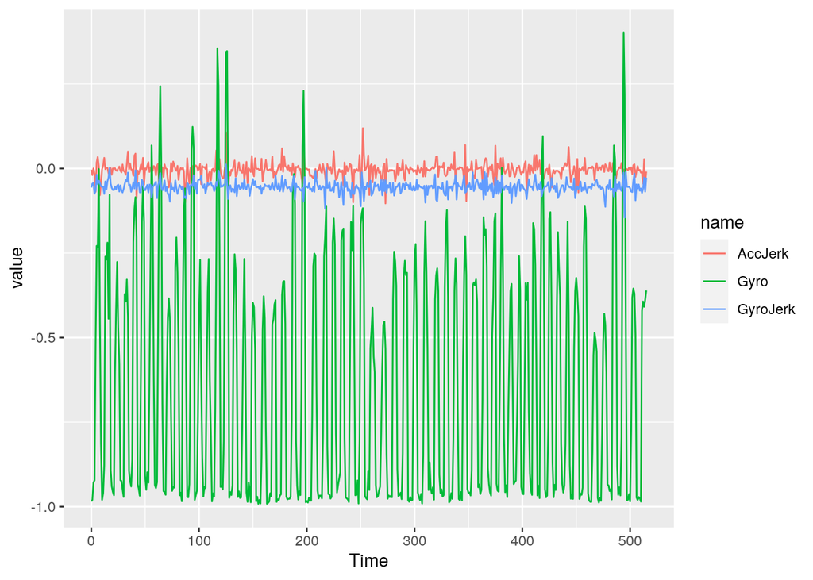

```r
X_final[,c("tBodyAccJerk_mean_Z", "tBodyGyroJerk_mean_Z", "fBodyGyro_mean_Z")] -> df
mutate(df, Time = round(1:nrow(df) / 20)) %>%
  group_by(Time) %>%
  summarise(AccJerk = mean(tBodyAccJerk_mean_Z),
            GyroJerk = mean(tBodyGyroJerk_mean_Z),
            Gyro = mean(fBodyGyro_mean_Z)) %>%
tidyr::pivot_longer(cols = 2:4, values_to = 'value', names_to = "name") %>%
  ggplot(aes(x = Time, y = value, col = name)) +
  geom_line()
```

## Związek danych ze zmienną celu

Wraz z odczytem z żyroskopu i akcelerometru, dostępna jest cecha dotycząca wykonywanej w danej chwili czynności. Oznaczona była jako zmienna celu dla problemu klasyfikacji (dlatego dla uproszczenia będzie tu nazywana zmienną celu). Jako że ma ona 6 klas, może być wykorzystana jako przykład dobrze wykonanej późniejszej klasteryzacji. Z poniższego histogramu możemy wywnioskować, że cecha ta jest dosyć dobrze zbalansowana.

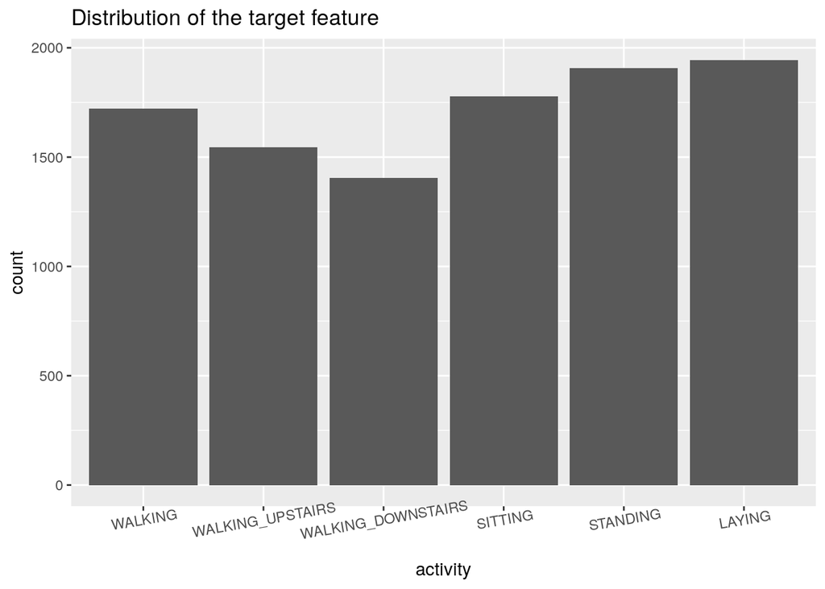

```r
ggplot() +
  aes(y) +
  geom_histogram(stat="count") +
  labs(title = "Distribution of the target feature") +
  xlab("activity") +
  theme(axis.text.x = element_text(angle = 10))
```

Warto zauważyć, że długość wektora średniego przyspieszenia jest podobna zarówno dla czynności w których ciało ma małą wartość prędkości (stanie, siedzenie, leżenie), jak i dużą (chodzenie). Wynika to z tego że zarówno mniejsze jak i większe ruchy są wykonywane z podobnym przyspieszeniem. Z tego powodu poniższe boxploty są do siebie zbliżone.

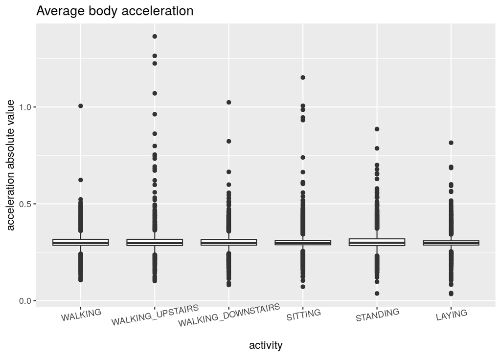

```r
mutate(X_final, tBodyAcc_mean
       = sqrt(X_final$tBodyAcc_mean_X^2 + X_final$tBodyAcc_mean_Y^2 + X_final$tBodyAcc_mean_Z^2)) %>%
  mutate(y=y) %>%
  ggplot() +
    geom_boxplot(aes(x=y, y=tBodyAcc_mean)) +
    labs(title = "Average body acceleration") +
    xlab("activity") +
    ylab("acceleration absolute value") +
    theme(axis.text.x = element_text(angle = 10))
```

Zwrócmy zatem uwagę na analogiczne odczyty dotyczące zrywu. Tutaj da się już zauważyć, iż w przypadku siedzenia lub leżenia mediana znalazła się niżej niż dla innych czynności, co daje nadzieję że wykorzystane w następych etapach algorytmy klasteryzacji dadzą wynik zbliżony do tego opisanego zmienną celu.

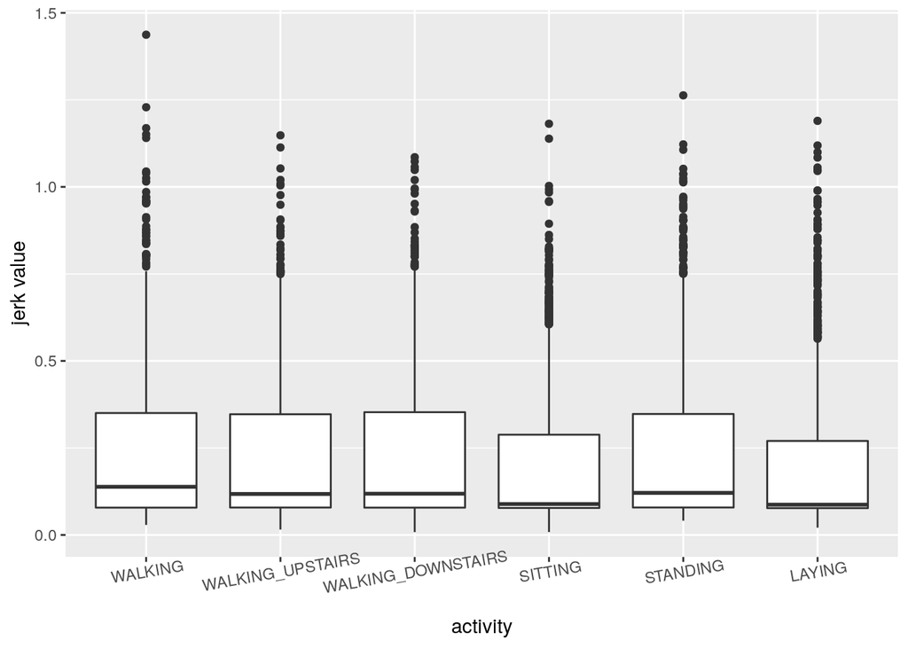

```r
mutate(X_mean, tBodyAccJerk_mean
       = sqrt(X_mean$tBodyAccJerk_mean_X^2 + X_mean$tBodyAccJerk_mean_Y^2 + X_mean$tBodyAccJerk_mean_Z^2)) %>%
  mutate(y=y) %>%
  ggplot() +
  geom_boxplot(aes(x=y, y=tBodyAccJerk_mean)) +
  xlab("activity") +
  ylab("jerk value") +
  theme(axis.text.x = element_text(angle = 10))
```

Co z pozostałymi zmiennymi? Okazuje się że największą co do modułu korelację ze zmienną celu ma tBodyGyro_arCoeff_X_2, ale jest ona zaledwie na poziomie -0.099.

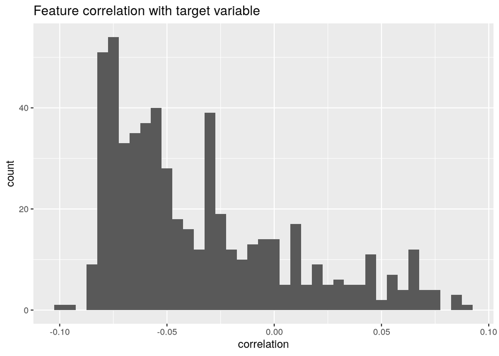

```r
ggplot() +
  geom_histogram(aes(x = cor(X, as.integer(y))), binwidth = 0.005) +
  labs(title = "Feature correlation with target variable") +
  xlab("correlation")
```